# Jordan Lake Reservoir Model

Part2: Data visualization of Model simulation for 1983-2018 period - 1

Smitom Borah

04/25/2023

Time required to run the entire notebook: ~10 mins

# 1 Motivation

In this notebook, we try to visualize the output generated in Part 1 (JLPMv016p001.Rmd).

# 2 Edit log

*No new edits since its creation.*

# 3 Introduction

In this notebook, we develop plots for the research article. Following plots are developed:

1. 1:1 observed vs predicted scatter plot
2. Times series of TP concentration
3. Mass Transfer plot

Let us load the packages and workspace of JLPMv016p001.Rmd first.

```r
# Clearing the working environment----
cat("\014"); rm(list=ls(all=TRUE)); graphics.off()
```

```r
# Start timer
Start_timer2 <- Sys.time()

# Loading the required packages
library(tidyverse)
library(gridExtra)
library(grid)
library(gridtext)
library(patchwork)
library(randomForest)
library(lubridate)

# Loading Rworkspace of JLPMv016p001.Rmd
load("RWorkSpaces/JLPMv016p001_1.RData")

# Loading the functions
# suppressMessages(source("Pmodels/functionsJorLak_no19.R"))
suppressMessages(source("Pmodels/JLPMfunv16p001.R"))
```

[output not shown]

Also, let us define basic plot elements before preparing the actual plots.

```r
plot_basics <- ggplot()+
  theme_bw()+
  theme(legend.background = element_blank(),
        panel.grid.major = element_blank(),
        panel.grid.minor = element_blank(),
        legend.text.align = 0,
        text = element_text(size = 10, color = "black"),
        legend.text = element_text(size = 10, color = "black"),
        axis.title = element_text(size = 10, color = "black"),
        axis.text = element_text(size = 10, color = "black"))
```

# 4 1:1 observed vs Predicted scatter plot

The 1:1 scatter plot of observed and predicted TP values is prepared in this section. We identify different segments with different colors and also report the coefficient of determination (R<sup>2</sup>) in the final plot.

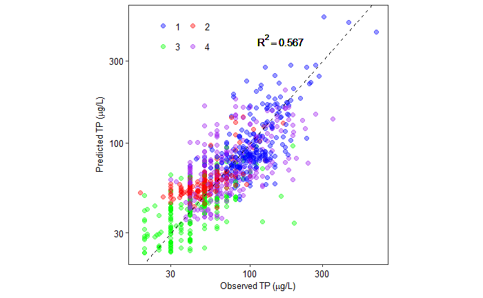

```r
# 1:1 scatter plot of observed and predicted TP concentration
TP_scatter <- plot_basics +
  geom_point(data = outff, aes(x = obs, y = value, color = variable), size =2, alpha = 0.4)+
  theme(legend.position = c(0.2,0.88),
        legend.background = element_rect(fill="transparent",
                                  size=0.5, linetype="blank",
                                  colour ="black"),
        legend.title.align = 0.5,
        # legend.box.margin = margin(10,10,6,6),
        legend.direction = "horizontal",
        aspect.ratio = 1)+
  xlim(0,700)+ylim(0,700)+
  scale_color_manual("",
                     labels = c("1", "2", "3", "4"),
                     values = c("blue", "red", "green", "purple"))+
  labs(x = expression(Observed~TP~"("*mu*g*"/"*L*")"),
       y = expression(Predicted~TP~"("*mu*g*"/"*L*")"))+
  geom_abline( intercept = 0, lty = 2)+
  guides(color=guide_legend(nrow=2, byrow=TRUE))+
  # geom_text(x = 500, y = 650, label = sprintf("italic(R^2) == %.3f", as.numeric(VarExp(outff[,"value"],outff[,"obs"]))) , parse = T)
  geom_text(data = outff,y = 2.60, x = 2.20, label = sprintf("R^2 == %.3f", as.numeric(VarExp(outff[,"value"],outff[,"obs"]))) , parse = T, size = 4)+
     scale_x_log10() +
     scale_y_log10()

TP_scatter
```

```r
# Creating an output file
# png(file="OutputFiles/JLPMv016_TPScatterPlot.png",height=4,width=6,units='in',res=1200)
# TP_scatter
# dev.off()
```

Let us try to recreate the above figure but add segment wise coefficient of determination and RMSE values.

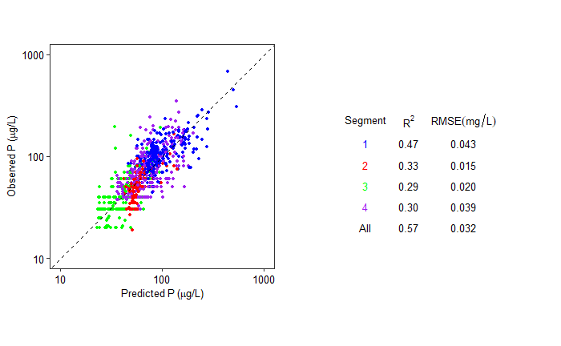

```r
# Creating a ggplot of scatter plot
TP_scatter1 <- plot_basics +
  geom_point(data = outff, aes(x = value , y = obs, color = variable), size =1)+
  theme(legend.position = "None",
        # legend.position = c(0.1,0.8),
        legend.background = element_rect(fill="transparent",
                                         size=0.5, linetype="blank",
                                         colour ="black"),
        legend.title.align = 0.5,
        # legend.box.margin = margin(10,10,6,6),
        legend.direction = "horizontal",
        aspect.ratio = 1)+
  # xlim(0,1000)+ylim(0,1000)+
  scale_color_manual("",
                     labels = c("1", "2", "3", "4"),
                     values = c("blue", "red", "green", "purple"))+
  labs(x = expression(Predicted~P~"("*mu*g*"/"*L*")"),
       y = expression(Observed~P~"("*mu*g*"/"*L*")"))+
  geom_abline( intercept = 0, lty = 2)+
  guides(color=guide_legend(nrow=4, byrow=TRUE))+
  # geom_text(x = 500, y = 650, label = sprintf("italic(R^2) == %.3f", as.numeric(VarExp(outff[,"value"],outff[,"obs"]))) , parse = T)
  # geom_text(data = outff,y = 2.60, x = 2.20, label = sprintf("R^2 == %.3f", as.numeric(VarExp(outff[,"value"],outff[,"obs"]))) , parse = T, size = 5)+
  scale_x_log10(limits = c(10,1000)) +
  scale_y_log10(limits = c(10,1000))+
  theme(axis.title = element_text(size = 10))

# TP_scatter1

# Creating a separate data frame of model performance
PModPer.df <- PModPer

# Tidying the data in the data frame
PModPer.df$Segment <- c("1", "2", "3", "4", "All")
PModPer.df$R2 <- round(as.numeric(PModPer.df$R2), digits = 2)

PModPer.df$RMSE <- round(PModPer.df$RMSE, digits = 3)
colnames(PModPer.df) <- c("Segment", "R^2", "RMSE (mg/L)")


# Preparing the tableGrob
PModPer.col <- matrix("black", nrow(PModPer.df),
                      ncol(PModPer.df))
PModPer.col[1:4,1] <- c("blue", "red", "green", "purple")
PModPer.fil <- matrix("transparent",
                      nrow(PModPer.df),
                      ncol(PModPer.df))

tt <- ttheme_minimal(core=list(fg_params =
                                 list(col = PModPer.col, cex = 0.8),
                               bg_params = list(col = NA)),
                     rowhead=list(bg_params = list(col=NA)),
                     colhead=list(fg_params = list(parse=TRUE, cex = 0.8),
                                  bg_params = list(col=NA)))

PModPer.df = tableGrob(PModPer.df, theme = tt, rows = NULL)

grid.arrange(TP_scatter1,PModPer.df,nrow = 1 )
```

```r
# Creating an output file
# png(file="OutputFiles/JLPMv016_TPScatterPlot.png",height=4,width=6,units='in',res=1200)
# grid.arrange(TP_scatter1,PModPer.df,nrow = 1 )
# dev.off()
```

# 5 Times series of TP concentration

## 5.1 Segment-wise TP reduction (%) from first to last decade

Let us first calculate how average TP concentrations have changed from first decade to the last decade.

```r
# Calculating average reduction in the TP concentration over first and last decade
ConcPdf <- MassFlows[,c("year", "mo", "C1", "C2sur", "C3sur", "C4sur")] %>%
  group_by(year) %>%
  summarise_at(.vars = c("C1", "C2sur", "C3sur", "C4sur"),
               .funs = mean)%>%
  mutate(decade = ifelse(year<=1992,
                         "first decade",
                         ifelse(year>=2009 & year<=2018, "last decade", NA))) %>%
  drop_na() %>%
  group_by(decade) %>%
  summarise_at(.vars = c("C1", "C2sur", "C3sur", "C4sur"),
               .funs = mean) %>%
  t  %>%
  janitor::row_to_names(.,1)%>%
  apply(.,2,as.numeric)%>%
  as.data.frame() %>%
  mutate(Pert_red = ((`first decade` - `last decade`)/`first decade`)*100,
         segment = c(1,2,3,4))

kableExtra::kable(head(ConcPdf[,c(4,1,2,3)]), "pipe",
                  col.names = c("Segment",
                                "First decade conc",
                                "Second decade conc",
                                "Percentage reduction"))
```

| Segment | First decade conc | Second decade conc | Percentage reduction |
| --- | --- | --- | --- |
| 1 | 154.22675 | 79.05135 | 48.74342 |
| 2 | 77.69308 | 55.99756 | 27.92465 |
| 3 | 54.78699 | 39.28508 | 28.29487 |
| 4 | 111.09916 | 63.56527 | 42.78510 |

## 5.2 Segment-wise TP reduction (%) in Periods 1, 2, and 3

If we divide the study period into 3 periods: period 1 (1983 – 1994), period 2 (1995 – 2006), and period 3 (2007 – 2018), let us see how the TP concentrations changed.

```r
# Calculating average reduction in the TP concentration over first and last decade
ConcPdf1 <- MassFlows[,c("year", "mo", "C1", "C2sur", "C3sur", "C4sur")] %>%
  group_by(year) %>%
  summarise_at(.vars = c("C1", "C2sur", "C3sur", "C4sur"),
               .funs = mean)%>%
  mutate(Period = ifelse(year<=1994,
                         "period1",
                         ifelse(year>=1995 & year<=2006,
                                "period2",
                                ifelse(year>=2007 & year<=2018,
                                "period3", NA)))) %>%
  drop_na() %>%
  group_by(Period) %>%
  summarise_at(.vars = c("C1", "C2sur", "C3sur", "C4sur"),
               .funs = mean) %>%
  t  %>%
  janitor::row_to_names(.,1)%>%
  apply(.,2,as.numeric)%>%
  as.data.frame() %>%
  mutate(Pert_red12 = ((`period1` - `period2`)/`period1`)*100,
         Pert_red23 = ((`period2` - `period3`)/`period2`)*100,
         Pert_red13 = ((`period1` - `period3`)/`period1`)*100,
         segment = c(1,2,3,4))

kableExtra::kable(head(ConcPdf1[,c(7,1,2,3,4,5,6)]), "pipe",
                  col.names = c("Segment",
                                "Period1 conc",
                                "Period2 conc",
                                "Period3 conc",
                                "Percentage reduction P1 to P2",
                                "Percentage reduction P2 to P3",
                                "Percentage reduction P1 to P3"))
```

| Segment | Period1 conc | Period2 conc | Period3 conc | Percentage reduction P1 to P2 | Percentage reduction P2 to P3 | Percentage reduction P1 to P3 |
| --- | --- | --- | --- | --- | --- | --- |
| 1 | 144.69129 | 91.62049 | 81.94108 | 36.67864 | 10.564678 | 43.36834 |
| 2 | 75.41607 | 61.08743 | 56.77302 | 18.99945 | 7.062680 | 24.72026 |
| 3 | 53.47223 | 43.05577 | 39.52921 | 19.48013 | 8.190679 | 26.07525 |
| 4 | 105.85812 | 73.63034 | 63.90401 | 30.44432 | 13.209677 | 39.63240 |

## 5.3 Overall TP reduction (%) in Periods 1, 2, and 3

Let us also calculate how overall TP changed in this reservoir:

```r
# Calculating average reduction in the TP concentration over first and last decade
ConcPdf2 <- MassFlows[,c("year", "mo", "C1", "C2sur", "C3sur", "C4sur")] %>%
  # Average concentration in Jordan Lake
  mutate(Avg_C = rowMeans(select(.,c(C1, C2sur, C3sur, C4sur)), na.rm = TRUE))%>%
  # Grouping by year
  group_by(year) %>%
  # Summarizing the average TP concentration
  summarise_at(.vars = c("Avg_C"),
               .funs = mean)%>%
  # Add the periods
  mutate(Period = ifelse(year<=1994,
                         "period1",
                         ifelse(year>=1995 & year<=2006,
                                "period2",
                                ifelse(year>=2007 & year<=2018,
                                "period3", NA)))) %>%
  drop_na() %>%
  # Grouping by Periods
  group_by(Period) %>%
  summarise_at(.vars =c("Avg_C"),
               .funs = mean) %>%
  t %>%
  janitor::row_to_names(row_number = 1)%>%
  apply(.,2,as.numeric)%>%
  t %>%
  as.data.frame()%>%
  mutate(Pert_red12 = ((`period1` - `period2`)/`period1`)*100,
         Pert_red23 = ((`period2` - `period3`)/`period2`)*100,
         Pert_red13 = ((`period1` - `period3`)/`period1`)*100)
kableExtra::kable(head(ConcPdf2), "pipe",
                  col.names = c("Period1 conc",
                                "Period2 conc",
                                "Period3 conc",
                                "Percentage reduction P1 to P2",
                                "Percentage reduction P2 to P3",
                                "Percentage reduction P1 to P3"))
```

| Period1 conc | Period2 conc | Period3 conc | Percentage reduction P1 to P2 | Percentage reduction P2 to P3 | Percentage reduction P1 to P3 |
| --- | --- | --- | --- | --- | --- |
| 94.85943 | 67.34851 | 60.53683 | 29.00178 | 10.11408 | 36.18259 |

Overall, percentage reduction in TP from period 1 to period 2 is 29.00 % and that from period 2 to 3 is 10.11 %

## 5.4 Predicted TP with prediction invertal

Now let us prepare the prediction interval. We plan to use 90% prediction interval for out study.

```r
# setting a timer
start_time <- Sys.time()

# Daily period of record
date.cali.daily <- floor_date(seq(ymd('1983-01-01'),
                                  ymd('2018-12-31'),
                                  by = 'day'),
                        unit = "day")



## Period of record
date_cali <- floor_date(seq(ymd('1983-01-01'),ymd('2018-12-01'), by = 'month'), unit = "month")


# Initial parameters
# Percentage reduction in external P loading
exPL00 <- -0
# Number of posterior parameter samples
N <- 1000

# Inputs ----
Popt_par <- opt_prm
PinpDF <- RoutMOdin
Pinp <- RoutMOdin %>% creaInp(.,tlim=nrow(.))
Pico <- Const_lis
Pico$timestep <- 1:length(Pinp$A1t)
Pico$vs_scal <- vs_scal
Pico$par_scal <- par_scal
Pico$Rbs2 <- BoSuP_MoDf$Seg2_Rp
Pico$Rbs3 <- BoSuP_MoDf$Seg3_Rp
Pico$Rbs4 <- BoSuP_MoDf$Seg4_Rp


# Setting seed
set.seed(5000)
# posterior samp
postPsmpl <- RAM$samples[seq((nrow(RAM$samples)-10000),nrow(RAM$samples),length.out =N),]

# Separating the observations ----
Pobs <- obs %>% transmute(cale_date=myd(paste0(as.character(ym),"-1")),
                          TPugL = obs,variable)

# Check for segments ----
all_seg <- Pobs %>% pull(variable) %>% unique # should 4 : "C1","C2","C3" and "C4"

# Loading the functions file ----
source("Pmodels/JLPMfunv16p002.R") # same as functionsJorLak_Feb22.R

# Setting up the dataframe to hold all the iteration in one space
## For Confidence interval
meanDFL00 <- tibble(sce_j=rep(exPL00, N),par_i=seq(1:N),Psim=vector("list",N))

## For Prediction interval
predDFL00 <- meanDFL00


## N iterations
for (i in 1:N){

  # Selecting the nutrient scenario and parameter set
  EP_red <-  meanDFL00[i, "sce_j"][[1]]
  parPi <- postPsmpl[meanDFL00[i, "par_i"][[1]],]


  # Arranging the dataset
  PinpCaSc <- PinpDF %>% creaInp(.,tlim=nrow(.))
  Pico$timestep <- 1:length(PinpCaSc$A1t)

  PmeanRes <- mod_wrap_pred_v3(inp_dat=PinpCaSc,
                               FixInp_lis=Pico,
                               CalPar=parPi) %>%
    dplyr::select(matches("C1|C.sur"),S1,S2,S3,S4,temperature) %>%
    `colnames<-`(substring(colnames(.),1,2)) %>%
    add_column(.,cale_date=c(date_cali))

  PmeanRes <- PmeanRes %>% mutate(S1res = (parPi["Rs"]/100)*S1*(parPi["ThetaR"]^(te-20)),
                                  S2res = (parPi["Rs"]/100)*S2*(parPi["ThetaR"]^(te-20)),
                                  S3res = (parPi["Rs"]/100)*S3*(parPi["ThetaR"]^(te-20)),
                                  S4res = (parPi["Rs"]/100)*S4*(parPi["ThetaR"]^(te-20)),
                                  Sconc = (S1+S2+S3+S4)/(49.02*10^3),
                                  Sres = (S1res+S2res+S3res+S4res)/(49.02*10^3))

  PpredRes <- PmeanRes %>%  # only adds observ error to Conc
    mutate_each(funs(sysanal.boxcox(., l1,l2)),-c(cale_date)) %>% # transform
    mutate_each(funs(.+rnorm(length(.),0,parPi["sy"])),-c(cale_date)) %>%  # add P error
    mutate_each(funs(sysanal.boxcox.inv(., l1,l2)),-c(cale_date)) # back transform

  meanDFL00[i,"Psim"][[1]] <- PmeanRes %>% list
  predDFL00[i,"Psim"][[1]] <- PpredRes %>% list

  svMisc::progress((i/N)*100)
  Sys.sleep(0.1)
  if (i == N) message("Done!")
}
# Ending the timer
end_time <- Sys.time()
```

Time taken to run the above code chunk:

```r
# Total tile taken
end_time - start_time
```

```
Time difference of 6.652161 mins
```

```r
# Function to calculate prediction interval
PI_func <- function(Cx, PI_low = 2.5, PI_high = 97.5){
  #------------------------------------------------------
  # Cx <- Segment Number
  # PI_low <- lower limit of Prediction Interval in %
  # PI_high <- upper limit of Prediction Interval in %
  #-------------------------------------------------------

  CI_TPx_L00_df <- meanDFL00 %>%
  pull("Psim") %>% sapply(.,"[[", Cx) %>% t
colnames(CI_TPx_L00_df) <- c(date_cali) %>% as.character()

CI_TPx_L00 <- apply(CI_TPx_L00_df, 2 ,quantile ,probs =c((PI_low/100),.5,(PI_high/100)))%>% t %>%
  as.data.frame()%>%
  tibble::rownames_to_column(var="cale_date")%>%
  mutate(cale_date=ymd(cale_date)) %>% rename_at(vars(-cale_date),function(x) paste0("cred",x))

### Adding observed values
CI_TPx_L00 <- Pobs %>% dplyr::filter(variable==Cx) %>% left_join(CI_TPx_L00,.)%>% dplyr::filter(year(cale_date)>=1983&year(cale_date)<=2099)  %>%
  as_tibble()

## Prediction interval ----
PI_TPx_L00_df <- predDFL00 %>%
  pull("Psim") %>% sapply(.,"[[", Cx) %>% t
colnames(PI_TPx_L00_df) <- c(date_cali) %>% as.character()

CI_TPx_L00 <- apply(PI_TPx_L00_df, 2 ,quantile ,probs =c((PI_low/100),.5,(PI_high/100))) %>%
  t %>% as.data.frame() %>%
  tibble::rownames_to_column(var="cale_date") %>%
  mutate(cale_date=ymd(cale_date)) %>%
  rename_at(vars(-cale_date),function(x) paste0("pred",x)) %>%
  left_join(CI_TPx_L00,.)

# Renaming the column names
colnames(CI_TPx_L00) <- c("cale_date", "cred_LowPI", "cred_Median", "cred_HighPI", "TPugL", "variable", "pred_LowPI", "pred_Median", "pred_HighPI")

return(CI_TPx_L00)
}

## Test run
C1testdf <- PI_func("C1")
### Test for anomally
anomaly.df1test <- C1testdf[which(C1testdf$`pred_LowPI`<C1testdf$`pred_LowPI`),]
anomaly.df2test <- C1testdf[which(C1testdf$`cred_HighPI`>C1testdf$`pred_HighPI`),]

# Segment wise TP calculation with 95% PI
## Segment 1
CI_TP1_L00 <- PI_func("C1", PI_low = 5, PI_high = 95)

## Segment 2
CI_TP2_L00 <- PI_func("C2", PI_low = 5, PI_high = 95)

## Segment 3
CI_TP3_L00 <- PI_func("C3", PI_low = 5, PI_high = 95)


## Segment 4
CI_TP4_L00 <- PI_func("C4", PI_low = 5, PI_high = 95)

# Segment wise Sediment P calculation with PI
## Segment 1
CI_S1_L00 <- PI_func("S1", PI_low = 5, PI_high = 95)

## Segment 2
CI_S2_L00 <- PI_func("S2", PI_low = 5, PI_high = 95)

## Segment 3
CI_S3_L00 <- PI_func("S3", PI_low = 5, PI_high = 95)


## Segment 4
CI_S4_L00 <- PI_func("S4", PI_low = 5, PI_high = 95)
```

```r
## Creating a combined dataset
### Segment 1
### TP
TP_predDF1 <- CI_TP1_L00[,c("cale_date","cred_Median", "pred_LowPI","pred_HighPI")] %>% mutate(Segment = rep("C1", nrow(CI_TP1_L00))) %>% rename(., Date = cale_date)

### Sediment P
S_predDF1 <- CI_S1_L00[,c("cale_date","cred_Median", "pred_LowPI","pred_HighPI")] %>% mutate(Segment = rep("C1", nrow(CI_S1_L00)))%>% rename(., Date = cale_date)

### Segment 2
### TP
TP_predDF2 <- CI_TP2_L00[,c("cale_date","cred_Median", "pred_LowPI","pred_HighPI")] %>% mutate(Segment = rep("C2", nrow(CI_TP2_L00)))%>% rename(., Date = cale_date)
### Sediment P
S_predDF2 <- CI_S2_L00[,c("cale_date","cred_Median", "pred_LowPI","pred_HighPI")] %>% mutate(Segment = rep("C2", nrow(CI_S2_L00)))%>% rename(., Date = cale_date)

### Segment 3
### TP
TP_predDF3 <- CI_TP3_L00[,c("cale_date","cred_Median", "pred_LowPI","pred_HighPI")] %>% mutate(Segment = rep("C3", nrow(CI_TP3_L00)))%>% rename(., Date = cale_date)
### Sediment P
S_predDF3 <- CI_S3_L00[,c("cale_date","cred_Median", "pred_LowPI","pred_HighPI")] %>% mutate(Segment = rep("C3", nrow(CI_S3_L00)))%>% rename(., Date = cale_date)

### Segment 4
### TP
TP_predDF4 <- CI_TP4_L00[,c("cale_date","cred_Median", "pred_LowPI","pred_HighPI")] %>% mutate(Segment = rep("C4", nrow(CI_TP4_L00)))%>% rename(., Date = cale_date)
### Sediment P
S_predDF4 <- CI_S4_L00[,c("cale_date","cred_Median", "pred_LowPI","pred_HighPI")] %>% mutate(Segment = rep("C4", nrow(CI_S4_L00)))%>% rename(., Date = cale_date)

# Observed values
outff_1 <- outff %>% mutate(Date = as.Date(paste0("1/",ym), format = "%d/%m/%Y"))

outff_2 <- outff_1 %>% rename(., Segment = variable)
outff_2 <- outff_2[,c(5,2:4)]

Segment_names <- c(`C1` = "Segment \n 1",
                   `C2` = "Segment \n 2",
                   `C3` = "Segment \n 3",
                   `C4` = "Segment \n 4")

# R^2
Seg1_R2 <- VarExp(outff[which(outff$variable=='C1'),"value"],outff[which(outff$variable=='C1'),"obs"])
Seg2_R2 <- VarExp(outff[which(outff$variable=='C2'),"value"],outff[which(outff$variable=='C2'),"obs"])
Seg3_R2 <- VarExp(outff[which(outff$variable=='C3'),"value"],outff[which(outff$variable=='C3'),"obs"])
Seg4_R2 <- VarExp(outff[which(outff$variable=='C4'),"value"],outff[which(outff$variable=='C4'),"obs"])

TP_R2_labels <- data.frame(Segment = c("C1", "C2", "C3", "C4"), R2 = sprintf("italic(R^2) == %.3f", as.numeric(c(Seg1_R2,Seg2_R2,Seg3_R2, Seg4_R2))))
```

Let us create a function to repeat the same task for each of the segments.

```r
# Function to plot the time series
TPS_func <- function(A, S_df,sf1= 1,sf2 = 0, TP_df, Cx){
  ## A -> Surface area in km^2
  ## S_df -> df containing sediment P predictions
  ## sf1 -> multiplicative scaling factor for secondary axis
  ## sf2 -> additive scaling factor for secondary axis
  ## TP_df -> df containing TP predictions
  ## Cx -> Segment as C1, C2, C3 or C4

  Sx_area <- A
  S_dfx <- S_df
  S_dfx[,c(2:4)] <- S_dfx[,c(2:4)]/(Sx_area*1000) # units in g/m^2
  S_dfx[,c(2:4)] <- ((S_dfx[,c(2:4)])/sf1) + sf2

  ## To check with the plot results
  S_dfy <- S_df
  S_dfy[,c(2:4)] <- (S_dfy[,c(2:4)]/(Sx_area*1000)) # units in g/m^2

  # Plot
  TPSx_plot <- ggplot()+
  theme_bw()+
  theme(legend.background = element_blank(),
        panel.grid.major = element_blank(),
        panel.grid.minor = element_blank(),
        legend.text.align = 0,
        text = element_text(size = 10, color = "black"),
        legend.text = element_text(size = 10, color = "black"),
        axis.text = element_text(size = 10, color = "black"),
        axis.title = element_text(size = 10, color = "black")) +
    # water TP 90% PI
    geom_ribbon(data = TP_df,
                aes(x = Date,
                    ymin = `pred_LowPI`,
                    ymax = `pred_HighPI`,
                    fill = "90% PI"),
                alpha = 0.5,
                show.legend = FALSE)+
    # sediment TP 90%
    geom_ribbon(data = S_dfx,
                aes(x = Date,
                    ymin = `pred_LowPI`,
                    ymax = `pred_HighPI`,
                    fill = "90% PI sed"),
                alpha = 0.5,
                show.legend = FALSE)+
    # Observed points
    geom_point(data = outff_2[which(outff_2$Segment== Cx),],
               aes(x = Date,
                   y = obs,
                   color = "Observed"),
               size = 1,
               alpha = 0.5)+
    # Predicted median line for water TP
    geom_line(data = TP_df,
              aes(x = Date,
                  y = `cred_Median`,
                  color = "Predicted1"))+
    # Predicted median line for sediment TP
    geom_line(data = S_dfx,
              aes(x = Date,
                  y = `cred_Median`,
                  color = "Predicted2"),
              lty = 2)+

    # Plot design
    scale_color_manual(values = c(`Observed` = "red",
                                  `Predicted1` = "black",
                                  `Predicted2` = "black"),
                       label = c(expression(P["w,obs"]),
                                 expression(P["w,pred"]),
                                 expression(P["s,pred"])),
                       guide = guide_legend(override.aes =
                                              list(size = c(2,0.5,0.5),
                                                   shape = c(19,NA,NA),
                                                   lty = c(NA,1,2),
                                                   fill=c(NA, NA,NA))))+
    scale_fill_manual(values = c(`90% PI` = "darkgrey",
                                 `90% PI sed` = "cornsilk3"))+
    scale_y_continuous(name = expression(TP[water]~"("*mu*g/L*")"),
                       sec.axis = sec_axis(trans = ~((.-sf2)*sf1) ,
                                           name = expression(atop(log(TP[sediments]),(g/m^2)))),
                     expand = c(0, 0))+
    scale_x_date(breaks = as.Date(c("1983-01-01", "1990-01-01", "2000-01-01", "2010-01-01", "2018-12-01")),date_labels = "%Y",
                 expand = c(0, 0))+
    theme(legend.position = "none",
          axis.title = element_blank())

  return(list(TPSx_plot,S_dfy ))
}

## test run
# TPS_plotx <- TPS_func(A = 11.94,
#                       S_df = S_predDF1,
#                       sf1 = 0.5,
#                       sf2 = 400,
#                       TP_df = TP_predDF1,
#                       Cx = "C1")
#
# TPS_plotx[[1]]
```

### 5.4.1 Segment 1

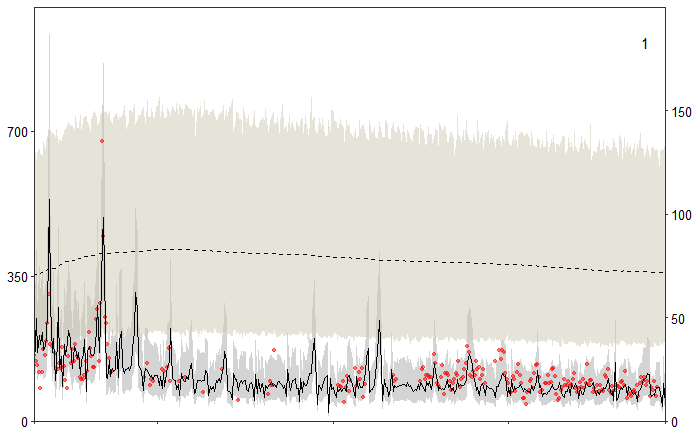

```r
# Segment 1
# Shape factors for secondary axes
shp_fctr11 <- 0.20
shp_fctr12 <- 0

TPS1_plot <- TPS_func(A = 11.94,
                      S_df = S_predDF1,
                      sf1 = shp_fctr11,
                      sf2 = shp_fctr12,
                      TP_df = TP_predDF1,
                      Cx = "C1")
TPS1_plot[[1]] <- TPS1_plot[[1]]+
  theme(axis.text.x = element_blank())+
        # axis.ticks.x = element_blank())+
  scale_y_continuous(name = expression(TP[water]~"("*mu*g/L*")"),
                       sec.axis = sec_axis(trans = ~((.-shp_fctr12)*shp_fctr11) ,
                                           name = expression(atop(log(TP[sediments]),(g/m^2))),
                     breaks = c(0,50,100,150)),
                     breaks = c(0, 350, 700),
                     limits = c(0,1000),
                     expand = c(0, 0))+
  annotate(geom = "text",
           x = as.Date("2018-01-01", format = "%Y-%m-%d"),
           y = 900,
           label = "1", hjust = 1, vjust = 0, size = 4)
TPS1_plot[[1]]
```

### 5.4.2 Segment 2

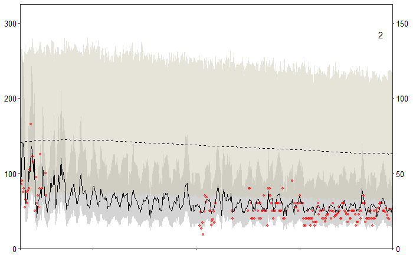

```r
# Segment 2
# Shape factors for secondary axes
shp_fctr21 <- 0.5
shp_fctr22 <- 0

TPS2_plot <- TPS_func(A = 12.92,
                      S_df = S_predDF2,
                      sf1 = shp_fctr21,
                      sf2 = shp_fctr22,
                      TP_df = TP_predDF2,
                      Cx = "C2")
TPS2_plot[[1]] <- TPS2_plot[[1]]+
  theme(axis.text.x = element_blank())+
        # axis.ticks.x = element_blank())+
  scale_y_continuous(name = expression(TP[water]~"("*mu*g/L*")"),
                       sec.axis = sec_axis(trans = ~((.-shp_fctr22)*shp_fctr21) ,
                                           name = expression(atop(log(TP[sediments]),(g/m^2))),
                     breaks = c(0,50,100,150,200, 250, 300, 350)),
                     breaks = c(0, 100, 200, 300),
                     limits = c(0,325),
                     expand = c(0, 0))+
  annotate(geom = "text", x = as.Date("2018-01-01", format = "%Y-%m-%d"), y = 280,
           label = "2", hjust = 1, vjust = 0, size = 4)
TPS2_plot[[1]]
```

### 5.4.3 Segment 3

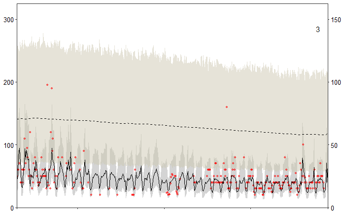

```r
# Segment 3
# Shape factors for secondary axes
shp_fctr31 <- 0.5
shp_fctr32 <- 0

TPS3_plot <- TPS_func(A = 17.28,
                      S_df = S_predDF3,
                      sf1 = shp_fctr31,
                      sf2 = shp_fctr32,
                      TP_df = TP_predDF3,
                      Cx = "C3")
TPS3_plot[[1]] <- TPS3_plot[[1]]+
  theme(axis.text.x = element_blank())+
        # axis.ticks.x = element_blank())+
  scale_y_continuous(name = expression(TP[water]~"("*mu*g/L*")"),
                       sec.axis = sec_axis(trans = ~((.-shp_fctr32)*shp_fctr31) ,
                                           name = expression(atop(log(TP[sediments]),(g/m^2))),
                     breaks = c(0,50,100,150,200, 250, 300, 350)),
                     breaks = c(0, 100, 200, 300),
                     limits = c(0,325),
                     expand = c(0, 0))+
  annotate(geom = "text", x = as.Date("2018-01-01", format = "%Y-%m-%d"), y = 280,
           label = "3", hjust = 1, vjust = 0, size = 4)
TPS3_plot[[1]]
```

### 5.4.4 Segment 4

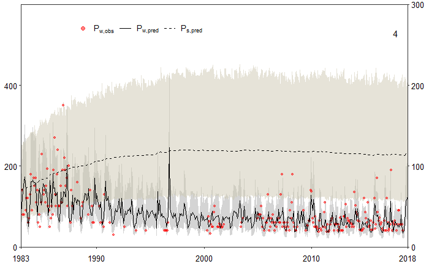

```r
# Segment 4
# Shape factors for secondary axes
shp_fctr41 <- 0.5
shp_fctr42 <- 0

TPS4_plot <- TPS_func(A = 6.057,
                      S_df = S_predDF4,
                      sf1 = shp_fctr41,
                      sf2 = shp_fctr42,
                      TP_df = TP_predDF4,
                      Cx = "C4")

TPS4_plot[[1]] <- TPS4_plot[[1]]+
  scale_y_continuous(name = expression(TP[water]~"("*mu*g/L*")"),
                       sec.axis = sec_axis(trans = ~((.-shp_fctr42)*shp_fctr41) ,
                                           name = expression(atop(log(TP[sediments]),(g/m^2))),
                     breaks = c(0,100,200,300)),
                     breaks = c(0, 200, 400),
                     limits = c(0,600),
                     expand = c(0, 0))+
    theme(legend.position = c(0.3,0.9),
          legend.background = element_blank(),
          legend.key = element_blank(),
        legend.title = element_blank(),
        legend.direction = "horizontal",
        # legend.background = element_rect(fill="transparent",
                                  # size=0.5, linetype="blank"),
        legend.text = element_text(size = 10),
        axis.text.x = element_text(vjust = -1))+
  annotate(geom = "text", x = as.Date("2018-01-01", format = "%Y-%m-%d"), y = 520,
           label = "4", hjust = 1, vjust = 0, size = 4)
TPS4_plot[[1]]
```

### 5.4.5 All plots together

```r
# Approach 1

# Remove axis titles from all plots
TPS_plots <- list(
  TPS1_plot[[1]],
  TPS2_plot[[1]],
  TPS3_plot[[1]],
  TPS4_plot[[1]]) %>%
  map(~.x + labs(x=NULL, y=NULL))
#
# gridtext
yleft <- textGrob(expression(P[w]~"("*mu*g/L*")"),
                  rot = 90, gp = gpar(fontsize = 10))

yright <- textGrob(expression(P[s]~(g/m^2)),
                   rot = 270, gp = gpar(fontsize = 10))

bottom <- textGrob("Years", gp = gpar(fontsize = 10, col="black"))
#
# # Lay out plots
# TPS_plot_all <- grid.arrange(grobs=TPS_plots, ncol = 1, nrow = 4,
#                     right = yright, left = yleft, bottom = bottom)

# tiff(file="OutputFiles/JLPMv016_TPS_all.png",height=8,width=8,units='in',res=600)
# TPS_plot_all
# dev.off()

# ggsave("OutputFiles/JLPMv016_TPS_all.tiff",TPS_plot_all,
#        height=6,width=10,units='in',dpi=600)

# Approach 2
TPS_plot_all2 <- { wrap_elements(yleft) +
    {{TPS_plots[[1]] / TPS_plots[[2]] / TPS_plots[[3]] / TPS_plots[[4]]}}  +
    wrap_elements(yright) +
    plot_layout(widths=c(1,16,1)) } /
  bottom +
  plot_layout(heights=c(98,4))
```

|  | t | l | b | r |
| --- | --- | --- | --- | --- |
| 1: | 1 | 1 | 1 | 1 |
| 2: | 1 | 2 | 1 | 2 |

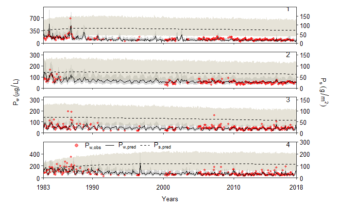

```r
TPS_plot_all2
```

```r
# Saving the plot
# ggsave("OutputFiles/JLPMv016_allTPS.png",TPS_plot_all2,
#        height=8,width=6,units='in',dpi=1200)
# dev.off()
```

While the figure here is not clear, the saved file in tiff or png is completely clear and can be view in the *Figures* folder.

### 5.4.6 Percentage of observed TP within prediction interval

Let us quickly estimate the percentage of TP that lie within the prediction interval.

```r
# Combining TP_predDF1, TP_predDF2, TP_predDF3, and TP_predDF4
TP_predDF <- rbind(TP_predDF1, TP_predDF2) %>%
  rbind(., TP_predDF3) %>%
  rbind(., TP_predDF4)

# Arranging the data frame by date
TP_predDF <- TP_predDF[order(TP_predDF$Date),]

# Creating another object to store the observed data
TP_obsDF <- Pobs %>% rename(., Date = cale_date, Segment = variable)

# Merging predicted TP data frame with observed TP data frame
TP_predDF <- merge(TP_predDF, TP_obsDF, by = c("Date", "Segment"), all.x = T)

# Total number of observed data
NobsP <- length(TP_obsDF$TPugL)

# data frame of observed data within 90 prediction interval
N90predPdf <- TP_predDF %>% drop_na() %>% .[which(.$`pred_LowPI`<= .$TPugL & .$`pred_HighPI` >= .$TPugL),]

# Total number of observed data within 90% prediction interval
N90predP <- nrow(N90predPdf)

# Creating a dataframe to summarize the results segment-wise
N90predPpertDF <- data.frame(Segment = c("C1", "C2","C3", "C4", "All"),
                             ObsN = c(nrow(TP_obsDF[which(TP_obsDF$Segment=="C1"),]),
                                      nrow(TP_obsDF[which(TP_obsDF$Segment=="C2"),]),
                                      nrow(TP_obsDF[which(TP_obsDF$Segment=="C3"),]),
                                      nrow(TP_obsDF[which(TP_obsDF$Segment=="C4"),]),
                                      nrow(TP_obsDF)),
                             PredN = c(nrow(N90predPdf[which(N90predPdf$Segment=="C1"),]),
                                       nrow(N90predPdf[which(N90predPdf$Segment=="C2"),]),
                                       nrow(N90predPdf[which(N90predPdf$Segment=="C3"),]),
                                       nrow(N90predPdf[which(N90predPdf$Segment=="C4"),]),
                                       nrow(N90predPdf))) %>%
  mutate(PertPinPI = (PredN/ObsN)*100)

# Presenting the data
N90predPpertDF
```

| Segment | ObsN | PredN | PertPinPI |
| --- | --- | --- | --- |
| C1 | 244 | 217 | 88.93443 |
| C2 | 202 | 197 | 97.52475 |
| C3 | 249 | 232 | 93.17269 |
| C4 | 249 | 203 | 81.52610 |
| All | 944 | 849 | 89.93644 |

```r
NA
```

### 5.4.7 Sediment P only

Although we have plotted the TP concentration in water and sediment columns in the above figures, we need to visualize these concentrations separately for each column, especially for sediment column, to see how the trends have actually changed. So, let us quickly plot the TP content in the sediment columns next. We just plot the median values here.

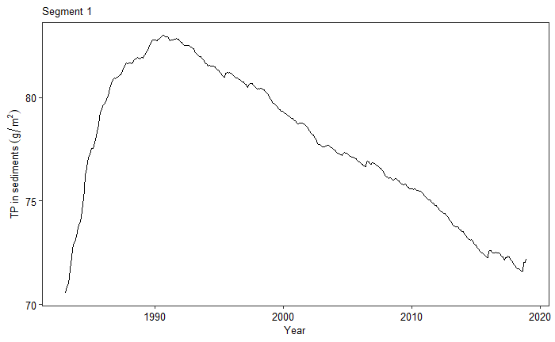

```r
# Changing the data from Mass to Concentration
S_predDF1C <- S_predDF1 %>% mutate_at(c("cred_Median", "pred_LowPI", "pred_HighPI"), function(x)(x/(11.94*1000)))

# ploting the sediment P concentration in Segment 1
plot_basics +
  geom_line(data = S_predDF1C,
            aes(x = Date, y = `cred_Median`))+
  # geom_ribbon(data = S_predDF1C,
  #             aes(x = Date,
  #                 ymin = `pred_LowPI`,
  #                 ymax = `pred_HighPI`),
  #             fill = "grey",
  #             alpha = 0.5,
  #             show.legend = FALSE)+
  labs(subtitle = "Segment 1",
       x = "Year",
       y = expression(TP~"in"~sediments~(g/m^2)))
```

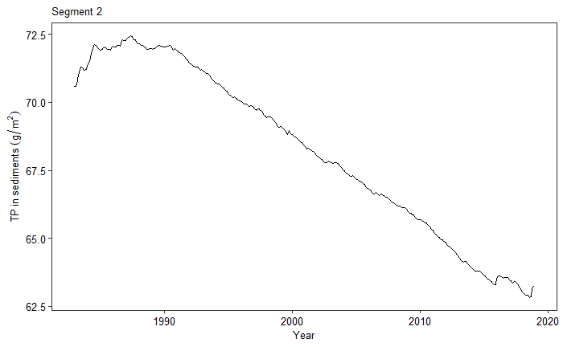

```r
# Changing the data from Mass to Concentration
S_predDF2C <- S_predDF2 %>% mutate_at(c("cred_Median", "pred_LowPI", "pred_HighPI"), function(x)(x/(12.92*1000)))

# ploting the sediment P concentration in Segment 2
plot_basics +
  geom_line(data = S_predDF2C,
            aes(x = Date, y = `cred_Median`))+
  # geom_ribbon(data = S_predDF2C,
  #             aes(x = Date,
  #                 ymin = `pred_LowPI`,
  #                 ymax = `pred_HighPI`),
  #             fill = "grey",
  #             alpha = 0.5,
  #             show.legend = FALSE)+
  labs(subtitle = "Segment 2",
       x = "Year",
       y = expression(TP~"in"~sediments~(g/m^2)))
```

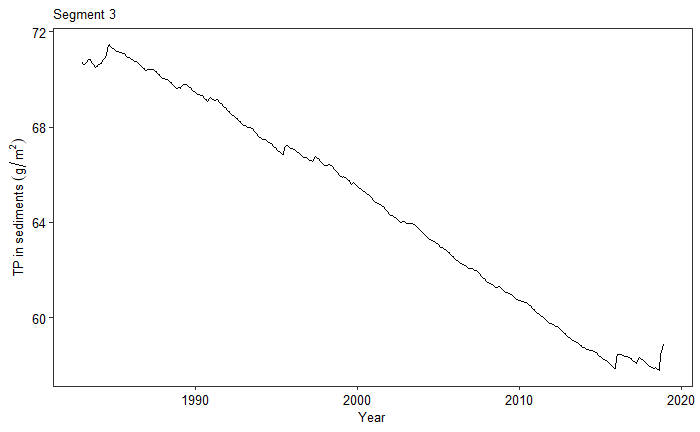

```r
# Changing the data from Mass to Concentration
S_predDF3C <- S_predDF3 %>% mutate_at(c("cred_Median", "pred_LowPI", "pred_HighPI"), function(x)(x/(17.28*1000)))

# ploting the sediment P concentration in Segment 3
plot_basics +
  geom_line(data = S_predDF3C,
            aes(x = Date, y = `cred_Median`))+
  # geom_ribbon(data = S_predDF3C,
  #             aes(x = Date,
  #                 ymin = `pred_LowPI`,
  #                 ymax = `pred_HighPI`),
  #             fill = "grey",
  #             alpha = 0.5,
  #             show.legend = FALSE)+
  labs(subtitle = "Segment 3",
       x = "Year",
       y = expression(TP~"in"~sediments~(g/m^2)))
```

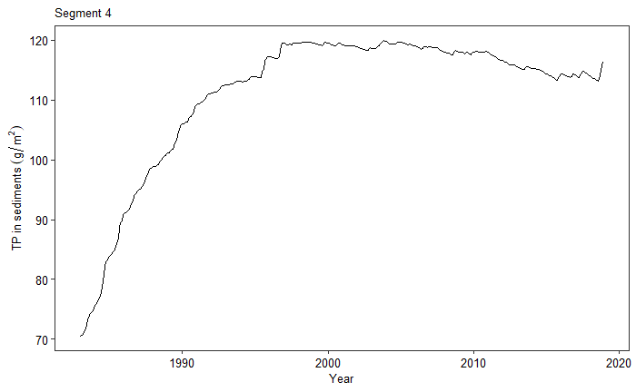

```r
# Changing the data from Mass to Concentration
S_predDF4C <- S_predDF4 %>% mutate_at(c("cred_Median", "pred_LowPI", "pred_HighPI"), function(x)(x/(6.057*1000)))

# ploting the sediment P concentration in Segment 4
plot_basics +
  geom_line(data = S_predDF4C,
            aes(x = Date, y = `cred_Median`))+
  # geom_ribbon(data = S_predDF4C,
  #             aes(x = Date,
  #                 ymin = `pred_LowPI`,
  #                 ymax = `pred_HighPI`),
  #             fill = "grey",
  #             alpha = 0.5,
  #             show.legend = FALSE)+
  labs(subtitle = "Segment 4",
       x = "Year",
       y = expression(TP~"in"~sediments~(g/m^2)))
```

Let us create a table to see the minimum and maximum of median sediment P in each segment:

| Segment | Min sed P (g/m<sup>2</sup>/mo) | Max sed P (g/m<sup>2</sup>/mo) |
| --- | --- | --- |
| 1 | 70.5529917 | 83.0016815 |
| 2 | 62.8215242 | 72.4430903 |
| 3 | 57.8028865 | 71.452301 |
| 4 | 70.5622418 | 119.924248 |

Now, let us look into some of the features observed in the sediment TP trends.

```r
# Calculating the annual average of sediment TP
S_predDFann <- data.frame(Date = S_predDF1C$Date,
                          year = year(S_predDF1C$Date),
                          S1 = S_predDF1C$`cred_Median`,
                          S2 = S_predDF2C$`cred_Median`,
                          S3 = S_predDF3C$`cred_Median`,
                          S4 = S_predDF4C$`cred_Median`) %>%
  group_by(year) %>%
  summarise_at(., .vars = c("S1", "S2", "S3", "S4"), .funs = mean)

print(S_predDFann)
```

| year | S1 | S2 | S3 | S4 |
| --- | --- | --- | --- | --- |
| 1983 | 71.96539 | 71.02912 | 70.68400 | 72.78110 |
| 1984 | 75.41816 | 71.83184 | 71.02374 | 79.28428 |
| 1985 | 78.37524 | 71.97361 | 71.09364 | 86.57057 |
| 1986 | 80.33709 | 72.13792 | 70.65763 | 92.67536 |
| 1987 | 81.28843 | 72.34190 | 70.31974 | 96.77340 |
| 1988 | 81.80495 | 72.05543 | 69.86347 | 99.76364 |
| 1989 | 82.36032 | 72.03767 | 69.68028 | 102.96189 |
| 1990 | 82.89049 | 72.02540 | 69.28469 | 107.07973 |
| 1991 | 82.81339 | 71.72970 | 69.03023 | 110.05575 |
| 1992 | 82.53478 | 71.31423 | 68.41262 | 111.75935 |

[output cut: 26 more lines]

As sediment TP constantly decreases in segments 2 and 3, we can easily estimate the percentage reduction in these segments during the study period:

In Segment 2, Percentage reduction in TP = 11.33 %

In Segment 3, Percentage reduction in TP = 17.82 %

In the other segments, the sediment TP increased and then decreased following the trends of external P loading (see the mass flow plot below). As these segments receive most of the tributaries, their response to external loading is most pronounced.

In segment 1, sediment TP increased by 15.07 % till 1991 and then started decreasing, a 13.28 % drop from 1992 to 2018.

In segment 4, sediment TP increased by 63.95 % till 2000 and then started decreasing, a 4.36 % drop from 2001 to 2018.

Now let us see the decadal variation of sediment P in Jordan Lake.

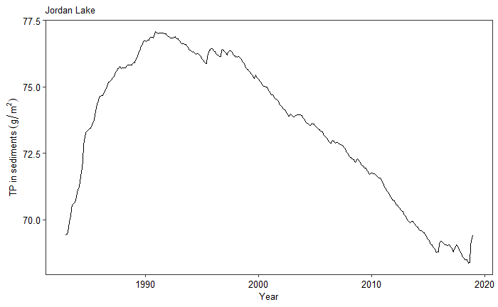

```r
# Overall sediment P concentration in Jordan Lake
S_predDFC <- PI_func("Sconc") %>% select(.,c("cale_date","cred_Median"))%>%
  rename(., Date = cale_date, Median = `cred_Median`)

# Ploting the overall trend
plot_basics +
  geom_line(data = S_predDFC,
            aes(x = Date, y = Median))+
  labs(subtitle = "Jordan Lake",
       x = "Year",
       y = expression(TP~"in"~sediments~(g/m^2)))
```

```r
# Calculating the decadal average
S_predDFC <- S_predDFC %>% mutate(Year = year(Date),
                                  Decade = ifelse(Year<=1992, "fdecade",ifelse(Year>=2009, "ldecade", NA))) %>% drop_na()

S_predDFCdec <- S_predDFC %>% group_by(Decade) %>%
  summarise(Savg = mean(Median))
```

Thus, sediment TP in Jordan Lake decreased by 6.57 %

# 6 Mass transfer plot

The annual inflow and outflow of P across the water column is shown in the plot below.

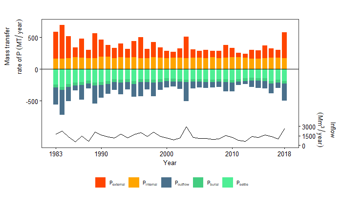

```r
# Creating a new data frame to create mass transfer plot
MT_df <- MassFlows %>%
  transmute(t = t,
            Year = year,
            P_inflow = Seg1in+Seg2in+Seg3in+Seg4in,
            P_recycle = S1res+S2res+S3res+S4res,
            P_outflow = outflow,
            P_settle = S1set+S2set+S3set+S4set,
            P_burial = S1Bur+S2Bur+S3Bur+S4Bur,
            P_water = M1 + M2 + M3 + M4) %>% group_by(Year) %>%
  summarise_at(vars(P_inflow:P_water),
               funs(sum)) %>%
  mutate(err = P_inflow+P_recycle-P_outflow-P_settle)

# Changing all the values into metric tons
MT_df[,2:8] <- MT_df[,2:8]/1000
## Making all outgoing terms negative
MT_df$P_outflow <- -MT_df$P_outflow
MT_df$P_settle <- -MT_df$P_settle
MT_df$P_burial <- -MT_df$P_burial
MT_df1 <- MT_df[,1:6]
# Adjust P_settle to make P_burial look part of P_settle
MT_df1$P_settle <- MT_df1$P_settle - MT_df1$P_burial

# gathering the data
MT_df_gat <- cbind(MT_df1[1], stack(MT_df1[2:6]))

MT_df_gat$ind <- factor(MT_df_gat$ind, levels = c("P_inflow","P_recycle", "P_outflow","P_burial","P_settle" ))

# Yearly flow into the reservoir
Flow_ann <- RoutMOdin[,c("year", "Q1in", "Q2in", "Q3in", "Q4in")]%>%
  mutate(Q_ann = Q1in+Q2in+Q3in+Q4in) %>% group_by(year) %>%
  summarise(Q_ann = sum(Q_ann))
Flow_ann$Q_ann1 <- (Flow_ann$Q_ann)/10-1200

# stacked plot

TP_MassTransfer <- ggplot(data = MT_df_gat)+
  # P control measure
  # geom_rect(aes(xmin = 2009, xmax = 2018, ymin = -Inf, ymax = Inf),fill = "grey", alpha = 0.01)+ # Jordan Lake rules (Partial adoption)
  geom_col(aes(x = Year, y = values, fill = ind), position = "stack", width = 0.75)+
  scale_fill_manual("",values=c("orange red","orange","skyblue4", "seagreen3", "seagreen2"),
                    label = c(expression(P[external]), expression(P[internal]), expression(P[outflow]), expression(P[burial]), expression(P[settle])))+
  labs(x = "Year")+
  scale_x_continuous(breaks = c(1983, 1990, 2000, 2010, 2018))+
  # Major hurricanes in North Carolina
  # geom_vline(xintercept = 1984, lty = 2, alpha = 0.5)+ # Hurricane Diana
  # geom_vline(xintercept = 1989, lty = 2, alpha = 0.5)+ # Hurricane Hugo
  # geom_vline(xintercept = 1996, lty = 2, alpha = 0.5)+ # Hurricane Fran
  # geom_vline(xintercept = 1999, lty = 2, alpha = 0.5)+ # Hurricane Flyod
  # geom_vline(xintercept = 2016, lty = 2, alpha = 0.5)+ # Hurricane Mathew
  # geom_vline(xintercept = 2018, lty = 2, alpha = 0.5)+ # Hurricane Florence
  # # Phosphorus control measures
  # geom_vline(xintercept = 1988, lty = 1, alpha = 0.5) # P ban in laundry detergent
  # geom_point(data = Flow_ann, aes(x = year, y = Q_ann))+
  geom_line(data = Flow_ann, aes(x = year, y = Q_ann1))+
  scale_y_continuous(name = expression(atop(Mass~transfer,rate~of~P~(MT/year))),
                     sec.axis = sec_axis(trans = ~(.+1200)*10, name = expression(atop(Inflow,(Mm^3/year))), breaks = c(0,1500, 3000)),
                     breaks = c(-500,0,500))+
  theme_bw()+
  geom_hline(yintercept = 0)+
  theme(panel.grid.major = element_blank(),
        panel.grid.minor = element_blank(),
        aspect.ratio = 0.5,
        legend.text.align = 0,
        legend.direction = "horizontal",
        # legend.position = c(0.5,0.1),
        legend.position = "bottom",
        text = element_text(size = 10, color = "black"),
        axis.title = element_text(size = 10, color = "black"),
        axis.text = element_text(size = 10, color = "black"),
        axis.ticks = element_line(color = "black"),
        axis.title.y = element_text(hjust = 1.00),
        panel.background = element_rect(fill = "transparent"),
        plot.background = element_rect(fill = "transparent", color = NA),
        legend.background = element_rect(fill = "transparent"),
        legend.box.background = element_rect(fill = "transparent", color = NA),
        legend.key = element_rect(fill = "transparent", colour = NA))






TP_MassTransfer
```

```r
# png(file="OutputFiles/JLPMv016_MassTransfer.png",height=4,width=6,units='in',res=1200)
# # tiff(file="OutputFiles/JLPMv016_MassTransfer.tiff",height=4,width=6,units='in',res=1200)
# TP_MassTransfer
# dev.off()
```

Let us also plot the mass transfer plot by months:

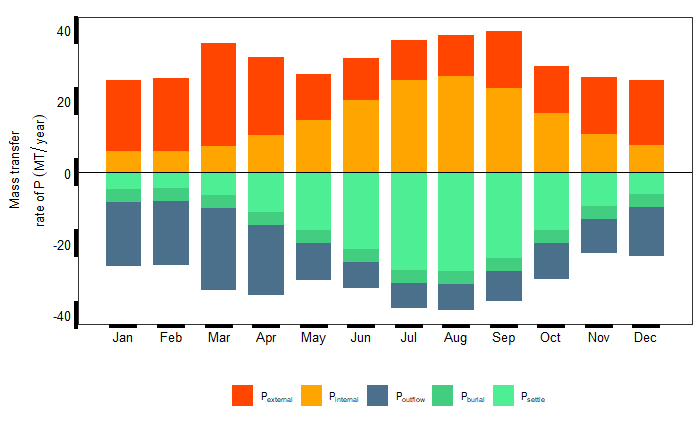

```r
# Creating a new data frame to create mass transfer plot
MT_df_mo <- MassFlows %>%
  transmute(t = t,
            Date = Date,
            Year = year,
            P_inflow = Seg1in+Seg2in+Seg3in+Seg4in,
            P_recycle = S1res+S2res+S3res+S4res,
            P_outflow = outflow,
            P_settle = S1set+S2set+S3set+S4set,
            P_burial = S1Bur+S2Bur+S3Bur+S4Bur,
            P_water = M1 + M2 + M3 + M4)

MT_df_mo$Date <- as.Date(MT_df_mo$Date, format = "%m/%d/%Y")

MT_df_mo <- MT_df_mo %>% mutate(mo = month(Date)) %>% group_by(mo) %>%
  summarise_at(vars(P_inflow:P_water),
               funs(mean))

# Changing all the values into metric tons
MT_df_mo[,2:7] <- MT_df_mo[,2:7]/1000

## Making all outgoing terms negative
MT_df_mo$P_outflow <- -MT_df_mo$P_outflow
MT_df_mo$P_settle <- -MT_df_mo$P_settle
MT_df_mo$P_burial <- -MT_df_mo$P_burial
MT_df_mo <- MT_df_mo[,1:6]

# Adjust P_settle to make P_burial look part of P_settle
MT_df_mo$P_settle <- MT_df_mo$P_settle - MT_df_mo$P_burial

# gathering the data
MT_df_gat_mo <- cbind(MT_df_mo[1], stack(MT_df_mo[2:6]))

MT_df_gat_mo$ind <- factor(MT_df_gat_mo$ind, levels = c("P_inflow","P_recycle", "P_outflow","P_burial","P_settle" ))

# Plotting the results
TP_MassTransfer_mo <- ggplot(data = MT_df_gat_mo)+
  geom_col(aes(x = mo, y = values, fill = ind), position = "stack", width = 0.75)+
  scale_fill_manual("",values=c("orange red","orange","skyblue4", "seagreen3", "seagreen2"),
                    label = c(expression(P[external]), expression(P[internal]), expression(P[outflow]), expression(P[burial]), expression(P[settle])))+
  labs(x = "",
       y = expression(atop(Mass~transfer,rate~of~P~(MT/year))))+
  scale_x_continuous(breaks = seq(1,12),
                     labels = month.abb)+
  theme_bw()+
  geom_hline(yintercept = 0)+
  theme(panel.grid.major = element_blank(),
        panel.grid.minor = element_blank(),
        aspect.ratio = 0.5,
        legend.text.align = 0,
        legend.direction = "horizontal",
        # legend.position = c(0.5,0.1),
        legend.position = "bottom",
        text = element_text(size = 10),
        axis.title = element_text(size = 10, color = "black"),
        axis.text = element_text(size = 10, color="black"),
        axis.ticks = element_line(size = 10, color = "black"))
        # panel.background = element_rect(fill = "transparent"),
        # plot.background = element_rect(fill = "transparent", color = NA),
        # legend.background = element_rect(fill = "transparent"),
        # legend.box.background = element_rect(fill = "transparent", color = NA),
        # legend.key = element_rect(fill = "transparent", colour = NA))

TP_MassTransfer_mo
```

```r
# Saving the plot
# png(file="OutputFiles/JLPMv016_MassTransfer_mo.png",height=4,width=6,units='in',res=1200)
# # tiff(file="OutputFiles/JLPMv016_MassTransfer_mo.tiff",height=4,width=6,units='in',res=1200)
# TP_MassTransfer_mo
# dev.off()
```

```r
# Let us add seasons to the monthly mass transfer plot
MT_df_mos <- MT_df_mo %>% mutate(Season = c('Winter','Winter', 'Winter', 'Spring', 'Spring', 'Spring', 'Summer', 'Summer', 'Summer', 'Fall', 'Fall', 'Fall'))

# Seasonal Mass transfer plot
MT_df_mos <- MT_df_mos %>%
  group_by(Season) %>%
  summarise_at(vars(P_inflow:P_burial),
               funs(mean))
# Relative contribution of P loads
MT_df_mos <- MT_df_mos %>%
  mutate(P_inflow_f = P_inflow/(P_inflow+P_recycle),
         P_recycle_f = P_recycle/(P_inflow+P_recycle))

# Printing the results
kableExtra::kable(head(MT_df_mos), "pipe")
```

| Season | P_inflow | P_recycle | P_outflow | P_settle | P_burial | P_inflow_f | P_recycle_f |
| --- | --- | --- | --- | --- | --- | --- | --- |
| Fall | 15.90919 | 11.582583 | -11.10181 | -10.670040 | -3.644539 | 0.5786891 | 0.4213109 |
| Spring | 15.53574 | 15.141498 | -12.54118 | -16.310435 | -3.642149 | 0.5064256 | 0.4935744 |
| Summer | 12.90463 | 25.529165 | -7.59077 | -26.444979 | -3.643715 | 0.3357626 | 0.6642374 |
| Winter | 23.13160 | 6.356568 | -19.54427 | -5.292605 | -3.643469 | 0.7844367 | 0.2155633 |

If we divide the study period into 3 periods: period 1 (1983 – 1994), period 2 (1995 – 2006), and period 3 (2007 – 2018), let us see how the average external and internal P loading has changed.

```r
# Creating a df to store mean P load in the first and last decade
MTstat_df <- MT_df %>%
  mutate(Period = ifelse(Year<=1994,
                         "period1",
                         ifelse(Year>=1995 & Year<=2006,
                                "period2",
                                ifelse(Year>=2007 & Year<=2018,
                                "period3", NA)))) %>%
  drop_na()

# Removing negative value
MTstat_df[,c(2:7)] <- abs(MTstat_df[,2:7])

# Calculating the average ratio of internal and external P load to
# total P load
MTstat_df <- MTstat_df %>%
  mutate(
    # total load
    Pin = P_inflow+P_recycle,
    #  P ratio of external P to total
    P_inflowfrac = P_inflow/Pin,
    # P ratio of internal P to total
    P_recyclefrac = P_recycle/Pin) %>%
  group_by(Period) %>% summarise_at(.vars = c("P_inflow", "P_recycle", "P_outflow", "P_settle", "P_burial", "Pin", "P_inflowfrac", "P_recyclefrac"), .funs = mean)

# showing the data
knitr::kable(head(MTstat_df), "pipe")
```

| Period | P_inflow | P_recycle | P_outflow | P_settle | P_burial | Pin | P_inflowfrac | P_recyclefrac |
| --- | --- | --- | --- | --- | --- | --- | --- | --- |
| period1 | 271.6556 | 176.4620 | 194.7816 | 250.6479 | 44.98257 | 448.1177 | 0.5766661 | 0.4233339 |
| period2 | 183.4455 | 175.5504 | 145.8380 | 205.8146 | 44.46111 | 358.9959 | 0.4879560 | 0.5120440 |
| period3 | 152.2293 | 175.4759 | 116.3827 | 203.1648 | 41.72118 | 327.7052 | 0.4365720 | 0.5634280 |

Let us how much P originally entered the reservoir before being shunted in the upstream tributary arms:

```r
# Removing the the shunting effect
MTstat_df_wo_sh <- MTstat_df %>% mutate(Ori_P_inflow = P_inflow/(1-as.numeric(output_prm["Sh"])))

# showing the data
knitr::kable(head(MTstat_df_wo_sh), "pipe")
```

| Period | P_inflow | P_recycle | P_outflow | P_settle | P_burial | Pin | P_inflowfrac | P_recyclefrac | Ori_P_inflow |
| --- | --- | --- | --- | --- | --- | --- | --- | --- | --- |
| period1 | 271.6556 | 176.4620 | 194.7816 | 250.6479 | 44.98257 | 448.1177 | 0.5766661 | 0.4233339 | 456.7533 |
| period2 | 183.4455 | 175.5504 | 145.8380 | 205.8146 | 44.46111 | 358.9959 | 0.4879560 | 0.5120440 | 308.4395 |
| period3 | 152.2293 | 175.4759 | 116.3827 | 203.1648 | 41.72118 | 327.7052 | 0.4365720 | 0.5634280 | 255.9537 |

Let us also see how the trends change from the first decade of study period to the last decade of the study period.

```r
# Creating a df to store mean P load in the first and last decade
MTstat_df1 <- MT_df %>%
  mutate(decade = ifelse(Year<=1992,
                         "decade1",
                         ifelse(Year>=2009 & Year<=2018,
                                "decade2",
                                NA))) %>%
  drop_na()

# Removing negative value
MTstat_df1[,c(2:7)] <- abs(MTstat_df1[,2:7])

# Calculating the average ratio of internal and external P load to
# total P load
MTstat_df1 <- MTstat_df1 %>%
  mutate(
    # total load
    Pin = P_inflow+P_recycle,
    #  P ratio of external P to total
    P_inflowfrac = P_inflow/Pin,
    # P ratio of internal P to total
    P_recyclefrac = P_recycle/Pin) %>%
  group_by(decade) %>% summarise_at(.vars = c("P_inflow", "P_recycle", "P_outflow", "P_settle", "P_burial", "Pin", "P_inflowfrac", "P_recyclefrac"), .funs = mean)

# showing the data
knitr::kable(head(MTstat_df1), "pipe")
```

| decade | P_inflow | P_recycle | P_outflow | P_settle | P_burial | Pin | P_inflowfrac | P_recyclefrac |
| --- | --- | --- | --- | --- | --- | --- | --- | --- |
| decade1 | 289.9990 | 175.5074 | 204.2486 | 258.5561 | 44.86616 | 465.5064 | 0.5933910 | 0.4066090 |
| decade2 | 161.4312 | 174.6120 | 123.0221 | 203.0513 | 41.48352 | 336.0433 | 0.4496836 | 0.5503164 |

The average internal P load in Jordan Lake is 175.83 MT/year. The average burial rate in Jordan Lake is 43.72 MT/year.

### 6.0.1 Alternate Mass transfer plot (No burial column)

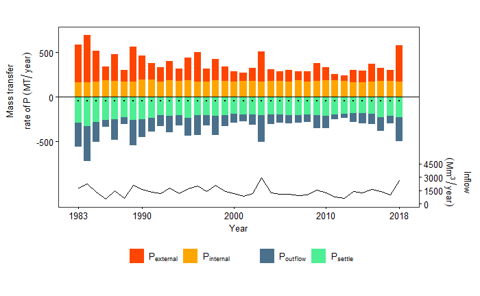

```r
# Creating a new data frame to create mass transfer plot (NB mean no burial data)
MT_df_NB <- MassFlows %>%
  transmute(t = t,
            Year = year,
            P_inflow = Seg1in+Seg2in+Seg3in+Seg4in,
            P_recycle = S1res+S2res+S3res+S4res,
            P_outflow = outflow,
            P_settle = S1set+S2set+S3set+S4set,
            P_burial = S1Bur+S2Bur+S3Bur+S4Bur,
            P_water = M1 + M2 + M3 + M4) %>% group_by(Year) %>%
  summarise_at(vars(P_inflow:P_water),
               funs(sum)) %>%
  mutate(err = P_inflow+P_recycle-P_outflow-P_settle)

# Changing all the values into metric tons
MT_df_NB[,2:8] <- MT_df_NB[,2:8]/1000
## Making all outgoing terms negative
MT_df_NB$P_outflow <- -MT_df_NB$P_outflow
MT_df_NB$P_settle <- -MT_df_NB$P_settle
MT_df_NB$P_burial <- -MT_df_NB$P_burial
MT_df_NB1 <- MT_df_NB[,1:6]

# Adjust P_settle to make P_burial look part of P_settle
# MT_df_NB1$P_settle <- MT_df_NB1$P_settle - MT_df_NB1$P_burial

# gathering the data
MT_df_NB_gat <- cbind(MT_df_NB1[1], stack(MT_df_NB1[2:6]))

MT_df_NB_gat$ind <- factor(MT_df_NB_gat$ind, levels = c("P_inflow","P_recycle","P_burial", "P_outflow","P_settle" ))

# Yearly flow into the reservoir
Flow_ann <- RoutMOdin[,c("year", "Q1in", "Q2in", "Q3in", "Q4in")]%>%
  mutate(Q_ann = Q1in+Q2in+Q3in+Q4in) %>% group_by(year) %>%
  summarise(Q_ann = sum(Q_ann))
Flow_ann$Q_ann1 <- (Flow_ann$Q_ann)/10-1200

# stacked plot

TP_MassTransfer_NB <- ggplot()+
  geom_col(data = MT_df_NB_gat, aes(x = Year, y = values, fill = ind), position = "stack", width = 0.75)+
  scale_fill_manual("",values=c("orange red","orange","transparent","skyblue4", "seagreen2"),
                    label = c(expression(P[external]), expression(P[internal]),"", expression(P[outflow]),expression(P[settle])))+
  labs(x = "Year")+
  scale_x_continuous(breaks = c(1983, 1990, 2000, 2010, 2018))+
  # geom_point(data = Flow_ann, aes(x = year, y = Q_ann))+
  geom_point(data = MT_df_NB1, aes(x = Year, y = P_burial), shape = 20, size = 0.8)+
    # geom_line(data = MT_df_NB1, aes(x = Year, y = P_burial), color = 'darkgray')+
  geom_line(data = Flow_ann, aes(x = year, y = Q_ann1))+
  scale_y_continuous(name = expression(atop(Mass~transfer,rate~of~P~(MT/year))),
                     sec.axis = sec_axis(trans = ~(.+1200)*10, name = expression(atop(Inflow,(Mm^3/year))), breaks = c(0,1500, 3000, 4500)),
                     breaks = c(-500,0,500))+
  theme_bw()+
  geom_hline(yintercept = 0)+
  theme(panel.grid.major = element_blank(),
        panel.grid.minor = element_blank(),
        aspect.ratio = 0.5,
        legend.text.align = 0,
        legend.direction = "horizontal",
        legend.position = "bottom",
        text = element_text(size = 10),
        axis.title = element_text(size = 10),
        axis.text = element_text(size = 10, color = "black"),
        legend.text = element_text(size = 10, color = "black"),
        axis.ticks = element_line(color = "black"),
        axis.title.y.left = element_text(hjust = 0.75),
        axis.title.y.right = element_text(hjust = 1),
        panel.background = element_rect(fill = "transparent"),
        plot.background = element_rect(fill = "transparent", color = NA),
        legend.background = element_rect(fill = "transparent"),
        legend.box.background = element_rect(fill = "transparent", color = NA),
        legend.key = element_rect(fill = "transparent", colour = NA))






TP_MassTransfer_NB
```

```r
# saving the plot
# png(file="OutputFiles/JLPMv016_MassTransfer_NB.png",height=4,width=6,units='in',res=1200)
# TP_MassTransfer_NB
# dev.off()
```

# 7 Monthly mass transfer plot

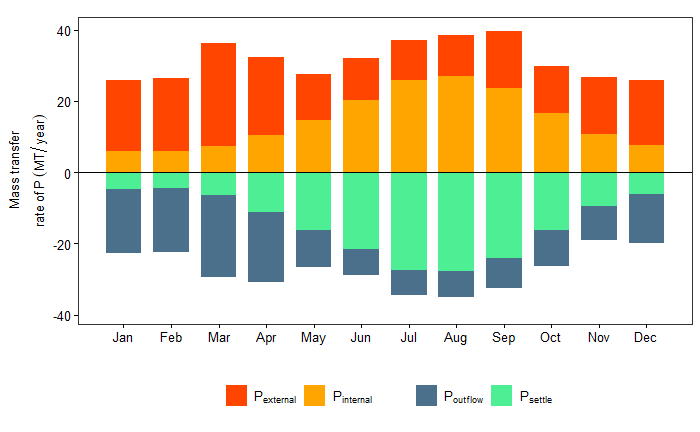

```r
# Creating a new data frame to create mass transfer plot
MT_df_mo_NB <- MassFlows %>%
  transmute(t = t,
            Date = Date,
            Year = year,
            P_inflow = Seg1in+Seg2in+Seg3in+Seg4in,
            P_recycle = S1res+S2res+S3res+S4res,
            P_outflow = outflow,
            P_settle = S1set+S2set+S3set+S4set,
            P_burial = S1Bur+S2Bur+S3Bur+S4Bur,
            P_water = M1 + M2 + M3 + M4)

MT_df_mo_NB$Date <- as.Date(MT_df_mo_NB$Date, format = "%m/%d/%Y")

MT_df_mo_NB <- MT_df_mo_NB %>% mutate(mo = month(Date)) %>% group_by(mo) %>%
  summarise_at(vars(P_inflow:P_water),
               funs(mean))

# Changing all the values into metric tons
MT_df_mo_NB[,2:7] <- MT_df_mo_NB[,2:7]/1000

## Making all outgoing terms negative
MT_df_mo_NB$P_outflow <- -MT_df_mo_NB$P_outflow
MT_df_mo_NB$P_settle <- -MT_df_mo_NB$P_settle
MT_df_mo_NB$P_burial <- -MT_df_mo_NB$P_burial
MT_df_mo_NB <- MT_df_mo_NB[,1:6]

# Adjust P_settle to make P_burial look part of P_settle
MT_df_mo_NB$P_settle <- MT_df_mo_NB$P_settle - MT_df_mo_NB$P_burial

# gathering the data
MT_df_gat_mo_NB <- cbind(MT_df_mo_NB[1], stack(MT_df_mo_NB[2:6]))

MT_df_gat_mo_NB$ind <- factor(MT_df_gat_mo_NB$ind, levels = c("P_inflow","P_recycle","P_burial", "P_outflow","P_settle" ))

# Plotting the results
TP_MassTransfer_mo_NB <- ggplot(data = MT_df_gat_mo_NB)+
  geom_col(aes(x = mo, y = values, fill = ind), position = "stack", width = 0.75)+
  scale_fill_manual("",values=c("orange red","orange", "transparent","skyblue4", "seagreen2"),
                    label = c(expression(P[external]), expression(P[internal]),"",expression(P[outflow]), expression(P[settle])))+
  labs(x = "",
       y = expression(atop(Mass~transfer,rate~of~P~(MT/year))))+
  scale_x_continuous(breaks = seq(1,12),
                     labels = month.abb)+
  theme_bw()+
  geom_hline(yintercept = 0)+
  theme(panel.grid.major = element_blank(),
        panel.grid.minor = element_blank(),
        aspect.ratio = 0.5,
        legend.text.align = 0,
        legend.direction = "horizontal",
        # legend.position = c(0.5,0.1),
        legend.position = "bottom",
        text = element_text(size = 10),
        axis.title = element_text(size = 10, color = "black"),
        axis.text = element_text(size = 10, color="black"),
        axis.ticks = element_line(color = "black"),
        legend.text = element_text(size = 10, color="black"))
        # panel.background = element_rect(fill = "transparent"),
        # plot.background = element_rect(fill = "transparent", color = NA),
        # legend.background = element_rect(fill = "transparent"),
        # legend.box.background = element_rect(fill = "transparent", color = NA),
        # legend.key = element_rect(fill = "transparent", colour = NA))

TP_MassTransfer_mo_NB
```

```r
# Saving the plot
# png(file="OutputFiles/JLPMv016_MassTransfer_mo_NB.png",height=4,width=6,units='in',res=1200)
# TP_MassTransfer_mo_NB
# dev.off()
```

# 8 Mass transfer plot for internal and external loading

```r
# Creating a new data frame to create mass transfer plot
MT_df_mo_NB1 <- MassFlows %>%
  transmute(t = t,
            Date = Date,
            Year = year,
            P_inflow = Seg1in+Seg2in+Seg3in+Seg4in,
            P_recycle = S1res+S2res+S3res+S4res)

MT_df_mo_NB1$Date <- as.Date(MT_df_mo_NB1$Date, format = "%m/%d/%Y")

MT_df_mo_NB1 <- MT_df_mo_NB1 %>% mutate(mo = month(Date)) %>% group_by(mo) %>%
  summarise_at(vars(P_inflow:P_recycle),
               funs(mean))

# Changing all the values into metric tons
MT_df_mo_NB1[,2:3] <- MT_df_mo_NB1[,2:3]/1000

# ## Making all outgoing terms negative
# MT_df_mo_NB1$P_outflow <- -MT_df_mo_NB1$P_outflow
# MT_df_mo_NB1$P_settle <- -MT_df_mo_NB1$P_settle
# MT_df_mo_NB1$P_burial <- -MT_df_mo_NB1$P_burial
# MT_df_mo_NB1 <- MT_df_mo_NB1[,1:6]

# Adjust P_settle to make P_burial look part of P_settle
# MT_df_mo_NB1$P_settle <- MT_df_mo_NB1$P_settle - MT_df_mo_NB1$P_burial

# gathering the data
MT_df_gat_mo_NB1 <- cbind(MT_df_mo_NB1[1], stack(MT_df_mo_NB1[2:3]))

MT_df_gat_mo_NB1$ind <- factor(MT_df_gat_mo_NB1$ind, levels = c("P_inflow","P_recycle"))

# Plotting the results
TP_MassTransfer_mo_NB1 <- ggplot(data = MT_df_gat_mo_NB1)+
  geom_col(aes(x = mo, y = values, fill = ind), position = "stack", width = 0.75)+
  scale_fill_manual("",values=c("orange red","orange"),
                    label = c(expression(External~P~load), expression(Internal~P~load)))+
  labs(x = "",
       y = expression(atop(Mass~transfer,rate~of~P~(MT/year))))+
  scale_x_continuous(breaks = seq(1,12),
                     labels = month.abb)+
  theme_bw()+
  geom_hline(yintercept = 0)+
  theme(panel.grid.major = element_blank(),
        panel.grid.minor = element_blank(),
        aspect.ratio = 0.5,
        legend.text.align = 0,
        legend.direction = "horizontal",
        # legend.position = c(0.5,0.1),
        legend.position = "bottom",
        text = element_text(size = 10),
        axis.title = element_text(size = 10),
        axis.text = element_text(size = 10, color="black"),
        axis.ticks = element_line(color = "black"),
        axis.text.x = element_text(angle = 90, vjust = 0.2),
        legend.text = element_text(size = 10, color="black"),
        panel.background = element_rect(fill = "transparent"),
        plot.background = element_rect(fill = "transparent", color = NA),
        legend.background = element_rect(fill = "transparent"),
        legend.box.background = element_rect(fill = "transparent", color = NA),
        legend.key = element_rect(fill = "transparent", colour = NA))

TP_MassTransfer_mo_NB1

# Saving the plot
png(file="OutputFiles/JLPMv016_TP_MassTransfer_mo_NB1.png",height=2.5,width=4,units='in',res=1200, bg = "transparent")
```

[figure not shown]

```r
TP_MassTransfer_mo_NB1
dev.off()
```

# 9 Saving the file

```r
# Saved on 04-28-2023
# save.image("RWorkSpaces/JLPMv016p002_1.RData")
```

```r
# Start timer
End_timer2 <- Sys.time()

# Total time taken to run the entire notebook
Tot_time2 <- End_timer2 - Start_timer2
Tot_time2
```

```
Time difference of 7.391245 mins
```

**Part 3:** 1. Prior and posterior distribution 2. Internal phosphorus loading